# Public health and economic problems for communities caused by severe weather events

Timo

5/17/2020

## Synopsis

In this report I aim to describe the effects of storms and other severe weather events on both public health and economic aspects. Many severe events can result in fatalities, injuries, and property damage, and preventing such outcomes to the extent possible is a key concern. To investigate this I obtained data from the U.S. National Oceanic and Atmospheric Administration’s (NOAA) storm database. This database tracks characteristics of major storms and weather events in the United States, including when and where they occur, as well as estimates of any fatalities, injuries, and property damage. From these data, I found that, tornadoes are by far the most harmful events with respect to population health. Floods ont the other hand have the greatest economic cosequences.

## Data Processing

### Information about the data

The data for this assignment come in the form of a comma-separated-value file compressed via the bzip2 algorithm to reduce its size.

- [Storm Data](https://d396qusza40orc.cloudfront.net/repdata%2Fdata%2FStormData.csv.bz2) [47Mb]

There is also some documentation of the database available. Here you will find how some of the variables are constructed/defined.

- National Weather Service [Storm Data Documentation](https://d396qusza40orc.cloudfront.net/repdata%2Fpeer2_doc%2Fpd01016005curr.pdf)
- National Climatic Data Center Storm Events [FAQ](https://d396qusza40orc.cloudfront.net/repdata%2Fpeer2_doc%2FNCDC%20Storm%20Events-FAQ%20Page.pdf)

```r
sourceFile <- "stormData.csv.bz2"
download.file("https://d396qusza40orc.cloudfront.net/repdata%2Fdata%2FStormData.csv.bz2", sourceFile)
```

### Loading storm data into R

```r
stormData <- read.csv(file = sourceFile)
```

### Exploring data

```r
str(stormData)
```

```
## 'data.frame':    902297 obs. of  37 variables:
##  $ STATE__   : num  1 1 1 1 1 1 1 1 1 1 ...
##  $ BGN_DATE  : Factor w/ 16335 levels "1/1/1966 0:00:00",..: 6523 6523 4242 11116 2224 2224 2260 383 3980 3980 ...
##  $ BGN_TIME  : Factor w/ 3608 levels "00:00:00 AM",..: 272 287 2705 1683 2584 3186 242 1683 3186 3186 ...
##  $ TIME_ZONE : Factor w/ 22 levels "ADT","AKS","AST",..: 7 7 7 7 7 7 7 7 7 7 ...
##  $ COUNTY    : num  97 3 57 89 43 77 9 123 125 57 ...
##  $ COUNTYNAME: Factor w/ 29601 levels "","5NM E OF MACKINAC BRIDGE TO PRESQUE ISLE LT MI",..: 13513 1873 4598 10592 4372 10094 1973 23873 24418 4598 ...
##  $ STATE     : Factor w/ 72 levels "AK","AL","AM",..: 2 2 2 2 2 2 2 2 2 2 ...
##  $ EVTYPE    : Factor w/ 985 levels "   HIGH SURF ADVISORY",..: 834 834 834 834 834 834 834 834 834 834 ...
##  $ BGN_RANGE : num  0 0 0 0 0 0 0 0 0 0 ...
##  $ BGN_AZI   : Factor w/ 35 levels "","  N"," NW",..: 1 1 1 1 1 1 1 1 1 1 ...
##  $ BGN_LOCATI: Factor w/ 54429 levels ""," Christiansburg",..: 1 1 1 1 1 1 1 1 1 1 ...
##  $ END_DATE  : Factor w/ 6663 levels "","1/1/1993 0:00:00",..: 1 1 1 1 1 1 1 1 1 1 ...
##  $ END_TIME  : Factor w/ 3647 levels ""," 0900CST",..: 1 1 1 1 1 1 1 1 1 1 ...
##  $ COUNTY_END: num  0 0 0 0 0 0 0 0 0 0 ...
```

[output cut: 23 more lines]

## Results

### 1. Across the United States, which types of events (as indicated in the EVTYPE variable) are most harmful with respect to population health?

Group storm data by event type.

```r
stormDataByEventType <- stormData %>% group_by(EVTYPE)
```

Add up the number of injuries by event type and sort the result in descending order.

```r
totalInjuries <-
    stormDataByEventType %>% summarise(total_injuries = sum(INJURIES, na.rm = T)) %>% arrange(desc(total_injuries))
```

Identify the five event types with the highest number of injuries.

```r
totalInjuriesHead <- totalInjuries %>% top_n(5)
print(totalInjuriesHead)
```

```
## # A tibble: 5 x 2
##   EVTYPE         total_injuries
##   <fct>                   <dbl>
## 1 TORNADO                 91346
## 2 TSTM WIND                6957
## 3 FLOOD                    6789
## 4 EXCESSIVE HEAT           6525
## 5 LIGHTNING                5230
```

Print a bar plot with the results.

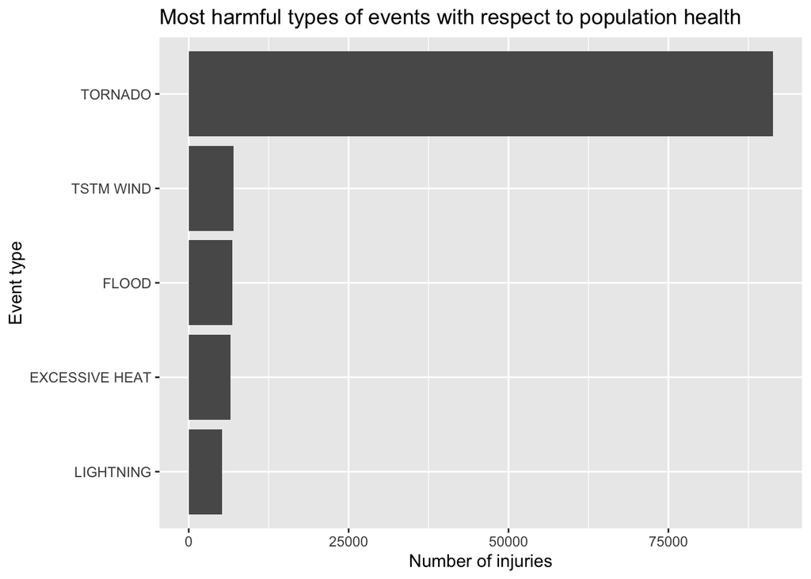

```r
library(ggplot2)
ggplot(totalInjuriesHead, aes(x = total_injuries, y = reorder(EVTYPE, total_injuries))) +
    geom_bar(stat = "identity") + labs(title = "Most harmful types of events with respect to population health", x = "Number of injuries", y = "Event type")
```

#### Answer

Tornadoes are by far the most harmful events with respect to population health.

### 2. Across the United States, which types of events have the greatest economic consequences?

The relevant fields are PROPDMG and CROPDMG. According to the documentation, alphabetical characters used to signify magnitude include “K” for thousands, “M” for millions, and “B” for billions. First step is to sum up the amount of propery damage by event type and sort the result in descending order.

```r
stormDataByEventType$PROPDMGEXP_clean <- 1
stormDataByEventType$PROPDMGEXP_clean[stormDataByEventType$PROPDMGEXP == "K"] <-
    1000
stormDataByEventType$PROPDMGEXP_clean[stormDataByEventType$PROPDMGEXP == "M"] <-
    1000000
stormDataByEventType$PROPDMGEXP_clean[stormDataByEventType$PROPDMGEXP == "B"] <-
    1000000000
```

Calculate total property damage by event type, sort them in descending order and pick the top five.

```r
totalPropertyDamage <-
    stormDataByEventType %>% summarise(total_propery_damage = sum(PROPDMG *
                                                                      PROPDMGEXP_clean, na.rm = T)) %>% arrange(desc(total_propery_damage))
totalPropertyDamageHead <- totalPropertyDamage %>% top_n(5)
print(totalPropertyDamageHead)
```

```
## # A tibble: 5 x 2
##   EVTYPE            total_propery_damage
##   <fct>                            <dbl>
## 1 FLOOD                    144657709807
## 2 HURRICANE/TYPHOON         69305840000
## 3 TORNADO                   56925660790.
## 4 STORM SURGE               43323536000
## 5 FLASH FLOOD               16140812067.
```

Then we have to sum up the amount of crop damage, in analogy to the property damage, by event type and sort the result in descending order.

```r
stormDataByEventType$CROPDMGEXP_clean <- 1
stormDataByEventType$CROPDMGEXP_clean[stormDataByEventType$CROPDMGEXP == "K"] <-
    1000
stormDataByEventType$CROPDMGEXP_clean[stormDataByEventType$CROPDMGEXP == "M"] <-
    1000000
stormDataByEventType$CROPDMGEXP_clean[stormDataByEventType$CROPDMGEXP == "B"] <-
    1000000000

totalCropDamage <-
    stormDataByEventType %>% summarise(total_crop_damage = sum(CROPDMG *
                                                                   CROPDMGEXP_clean),
                                       na.rm = T) %>% arrange(desc(total_crop_damage))
totalCropDamageHead <- totalCropDamage %>% top_n(5)
print(totalCropDamageHead)
```

```
## # A tibble: 985 x 3
##    EVTYPE            total_crop_damage na.rm
##    <fct>                         <dbl> <lgl>
##  1 DROUGHT                 13972566000 TRUE
##  2 FLOOD                    5661968450 TRUE
##  3 RIVER FLOOD              5029459000 TRUE
##  4 ICE STORM                5022113500 TRUE
##  5 HAIL                     3025537890 TRUE
##  6 HURRICANE                2741910000 TRUE
##  7 HURRICANE/TYPHOON        2607872800 TRUE
##  8 FLASH FLOOD              1421317100 TRUE
##  9 EXTREME COLD             1292973000 TRUE
## 10 FROST/FREEZE             1094086000 TRUE
## # … with 975 more rows
```

#### Answer

The most devastating weather event with the greatest economic cosequences (to property and crops) are floods.